ANALYSIS OF LEAGUE OF LEGENDS PLAYSTYLES OF DIFFERENT REGIONS IN PROFESSIONAL PLAY (Season 5) BY: Edmund Li

1.Introduction

League of Legends is a game that swept the world with over 100 million active players. It is a MOBA (Multiplayer Online Battle Arena) that requires precise teamwork and creativity to carefully craft a team to win your games. It is a 5v5 arena battler with over 100 characters you can choose from. Each team has five roles that have their unique roles. These roles consist of the Top Laner, Mid Laner, Jungler, ADC (Attack Damage Carry), and Support. Together they play throughout a single map. Each of these characters procure gold in the map to become stronger so they can more succesfully win the game.In this map each side has three turrets spread through three lanes (Top, Middle and Bottom). These towers defend a base in the corner called the Nexus which is defended by two additional turrets. The objective this game is to destroy enemy turrets while fending off the enemy team, to eventually make way to the Nexus to destroy it. To learn more you can look at their website here (https://www.leagueoflegends.com/en-us/how-to-play/?_gl=1*1nkm87e*_ga*MTI5ODY5MTkyMC4xNjM5ODYwMzc2*_ga_FXBJE5DEDD*MTYzOTkxODMwNC4zLjAuMTYzOTkxODMwNC42MA..)

League of Legends keeps track of many games in a large match history database. This data is procured by league of legends and released by them for players to keep track of their games. They also provide this data for third parties and encourage others to use the data to be able to analyze trends and gameplay.

Games easily fall into a pattern where there is one succesful strategy to win the game. I believe a great video game with depth allows for teams to create their own unique playstyle that can be succesful at even the highest level.So in this tutorial, I will be using the data given by League of Legends to analyze professional play to see if regions show signs of different playstyles to see if League of Legends is a game that allows for creative skill expression. To understand this I will be reading and tidying data to analyze the various character picks, role gold distribution, and turret destroying patterns of the five different regions of pro play to see if we can see different playstyles between regions.

But before we get into it we must first define what a playstyle is. Since this is such an ambiguous term we will be defining it as how a team proactively tries to take control of the game. This means what characters they choose, and what they objectives(turrets) and roles they proactively choose to invest their resources into. If you dont know to much about league watch this quick video made by League of Legends that quickly explains how the game works here. (https://www.youtube.com/watch?v=l4bf7pjcYYw&ab_channel=LeagueofLegends)

2.Data Collection

To collect data, I am parsing CSV files that contains information I need to complete my analysis. I found my data on kaggle and it could be found here (https://www.kaggle.com/chuckephron/leagueoflegends?select=LeagueofLegends.csv). In this sections I import various libraries such as pandas and matplotlib to aid with my analysis later on in this tutorial and read the csv file I have downloaded of kaggle. This content includes data on every professional match played in all five regions (NALCS: North America, EULCS: European Union, LCK: Korea, LMS: Taiwan, Hong Kong and Macau, and TCL: Turkey). This data includes champion picks of each role, net worth in gold per minute for each roll, and much more specific data we need to complete this tutorial.

```python
import time
import csv
import requests
from bs4 import BeautifulSoup
import pandas as pd
import urllib.parse as urllib
import statsmodels.formula.api as smf
from sklearn.linear_model import LinearRegression
import matplotlib.pyplot as plt
import matplotlib
import seaborn as sns


#Read the League of Legend match data in the form of a csv
league = pd.read_csv("LeagueOfLegends.csv")
league.head()
```

Here I saved the game data into seperate dataframes. While doing so I isolate the various data that I need. Since season 5 was my personal favorite season I chose to analyze season 5's data when doing my analysis. With this decision, I first isolated all of the games played in 2015 (Season 5) into a dataframe. Knowing that I wanted to analyze only the highest level of play, I isolated only games played in-season into a smaller dataframe as they are the games with the highest stakes. This means that it will be more representative of top-level play as apposed to the more experimental off-season. I took my new dataframe and split it into five different dataframes based on their region so I can seperately analyze each regions gameplay to look for differences in gameplay.

```python
#Isolate games from season 5
s5 = league.loc[league['Year'] == 2015]

#Isolate in-season games
s5 = s5.loc[league['Type'] == 'Season']


#Seperate season 5 in-season games into their 5 respective regions
nalcs5 = s5.loc[s5['League'] == 'NALCS']
eulcs5 = s5.loc[s5['League'] == 'EULCS']
lck5 = s5.loc[s5['League'] == 'LCK']
lms5 = s5.loc[s5['League'] == 'LMS']
tcl5 = s5.loc[s5['League'] == 'TCL']
```

Now we are ready to manipulate the data into sets we need for analysis.

3.Data Processing and Munging

Since our data are individual games, we need our data to reflect all games so for this reason I chose to grab data from the main data set to more concise smaller dataFrames for future analysis. Since our first section of analysis is based on character picks based on role and region, we first have to grab all the characters picked. However since our dataFrame has this seperate by teams, we have to be able to combine both teams picks into a singular data set while seperating the picks per region to be able to differentiate each regions picks.

To do this I created a helper that could combine blue side and red side character pick counts into one dataframe. With this I was able to also create seperate dataframes based on each of the roles and regions.

You may remember that there was a total of five roles, yet I only chose to analyze four. This is because the bottom lane has two roles in the same lane, the support and the ADC. The reason I chose to leave out the ADC is because in this lane the playstyles are usually dictated by the support rather than the ADC. Supports characters have variety of playstyles while the ADC's playstyle is very similar and usually depends on their support and the opposing support. This means that the support give a much more accurate depiction on a teams playstyle and goals.

```python
#Helper function to return a dataFrame with combined character picks.
def chartHelp(dataFrame,blueString,redString):
    #Grab the counts of picks per character on the blue side
    blueTop = dataFrame[blueString].value_counts()
    #Grab the counts of picks per character on the red side
    redTop = dataFrame[redString].value_counts()
    #Combine data into one data frame
    result = pd.concat([blueTop, redTop], axis=1).reindex(blueTop.index)
    #Fill all not available data with zeroes to allow for further manipulation
    result = result.fillna(0)
    #Add the champion picks of both blue and red side into a new column
    sumPicks = result[blueString] + result[redString]
    result["SeasonPicks"] = sumPicks
    return result

#Top Lane Charts
resultNATop = chartHelp(nalcs5,'blueTopChamp','redTopChamp')
resultLCKTop = chartHelp(lck5,'blueTopChamp','redTopChamp')
resultEUTop = chartHelp(eulcs5,'blueTopChamp','redTopChamp')
resultLMSTop = chartHelp(lms5,'blueTopChamp','redTopChamp')
resultTCLTop = chartHelp(tcl5,'blueTopChamp','redTopChamp')

#Mid Lane Charts
resultNAMid = chartHelp(nalcs5,'blueMiddleChamp','redMiddleChamp')
resultLCKMid = chartHelp(lck5,'blueMiddleChamp','redMiddleChamp')
resultEUMid = chartHelp(eulcs5,'blueMiddleChamp','redMiddleChamp')
resultLMSMid = chartHelp(lms5,'blueMiddleChamp','redMiddleChamp')
resultTCLMid = chartHelp(tcl5,'blueMiddleChamp','redMiddleChamp')

#Support Charts
resultNASup = chartHelp(nalcs5,'blueSupportChamp','redSupportChamp')
resultLCKSup = chartHelp(lck5,'blueSupportChamp','redSupportChamp')
resultEUSup = chartHelp(eulcs5,'blueSupportChamp','redSupportChamp')
resultLMSSup = chartHelp(lms5,'blueSupportChamp','redSupportChamp')
resultTCLSup = chartHelp(tcl5,'blueSupportChamp','redSupportChamp')

#Jungle Charts
resultNAJg = chartHelp(nalcs5,'blueJungleChamp','redJungleChamp')
resultLCKJg = chartHelp(lck5,'blueJungleChamp','redJungleChamp')
resultEUJg = chartHelp(eulcs5,'blueJungleChamp','redJungleChamp')
resultLMSJg = chartHelp(lms5,'blueJungleChamp','redJungleChamp')
resultTCLJg = chartHelp(tcl5,'blueJungleChamp','redJungleChamp')
```

Our next section of analysis is now looking at the gold distribution between roles and regions. The reason why analyzing this is important is because we can see what roles different regions like to play for. Since gold is a limited resource spawned on the map on timer in form of minions, creeps and taking down other players it is important to look at because it can show us what role certain regions may like to play around (Meaning that they invest in certain roles more by giving it more access to gold so they specifically can get stronger to do their role well).

To do this I made another helper function that would take in a dataframe to parse the first 20 minutes of net worth of each role per game. The reason I chose 20 minutes is because that is where most of the gameplan decisions are made. It also prevents faulty data because not every game has the same minute count. In this helper function I would first append both gold worth of the red side and blueside to a single dataframe. Since they are in the form of a list in string for I would have to parse and turn it back into list form so I can further manipulate it. As I do this for each minute, I find the average of all the gold values for that time so I can end with a list that has the average gold for every minute per role.

```python
roles = [['goldredTop','goldblueTop'],['goldredMiddle','goldblueMiddle'],['goldredADC','goldblueADC'],['goldredJungle','goldblueJungle']]
rolesOrder = ['top','middle','adc','jungle']
minutes = ["1","2","3","4","5","6","7","8","9","10","11","12","13","14","15","16","17","18","19","20"]

#Helper Function

def getList(dataFrame):
    finList = []
    #loops through each role
    for role in roles:
        #for each role I will append both blue and red sides gold worth per minute to a dataframe
        result = dataFrame[role[0]].append(dataFrame[role[1]]).reset_index(drop=True)
        lists = []

        #Then I parse the string and convert the string to a list I can work with
        for entry in result:
            y = entry
            y = y.replace("[", "")
            y = y.replace("]", "")
            z = y.split(", ")
            #I grab the first 20 minutes of the game
            if len(z[:21]) == 21:
                lists.append(z[:21])

        finAverage = []
        #Go through all the goldWorth lists and find the average for each minute.
        for x in range(0,20):
            sum = 0
            for entry in lists:
                sum = sum + int(entry[x])
            average = sum/(len(lists))
            finAverage.append(average)

        finList.append(finAverage)
    #return a list of the average gold at each minute per role.
    return finList
```

For my last section I chose to analyze which turrets teams preferred to take during games. This is important because this shows how different regions may like to approach taking the game. Previously we explored the concept of investing into a certain role (or lane). Similarly we can see how different regions like to invest their time in which parts of the map. As stated before there are three lanes with turrets defending the base. Here we organize data so we can see which lanes regions prefer to use to make a free path into the enemy base to destroy their nexus.

To organize this data first must take the column in our dataframe that shows what turrets were destroyed throughout the game. You might notice that we only chose to take the winning teams data (when their (b/r)result is equal to one). This is because the winning team tends to be in a state where they are proactively using their gameplan to take turrets. The losing team usually are weaker, meaning that they are not in a state to be able to execute their gameplan and rather play reactionary to the other team. This means that the losing teams data does not accurately measure a teams playstyle and decision making.

So after we take the turretsDestroyed data from our created dataframes, we then convert our string data into a actual list. So to do this before we collect our data, we convert it into a list using a library called ast. This library allows us to parse lists in string form into list form. After doing so I create a helper function to count which of the nine main turrets are destroyed by the winning team based on region.

```python
import ast

towerListNA = []
towerListEU = []
towerListLCK = []
towerListLMS = []
towerListTCL = []
#Go through All the regions and append the turretData of the winning team
for index, row in nalcs5.iterrows():
    if row[6] == 1:
        for i in ast.literal_eval(row[19]):
            towerListNA.append(i)
    elif row[5] == 1:
        for i in ast.literal_eval(row[12]):
            towerListNA.append(i)
for index, row in eulcs5.iterrows():
    if row[6] == 1:
        for i in ast.literal_eval(row[19]):
            towerListEU.append(i)
    elif row[5] == 1:
        for i in ast.literal_eval(row[12]):
            towerListEU.append(i)
for index, row in lck5.iterrows():
    if row[6] == 1:
        for i in ast.literal_eval(row[19]):
            towerListLCK.append(i)
    elif row[5] == 1:
        for i in ast.literal_eval(row[12]):
            towerListLCK.append(i)
for index, row in lms5.iterrows():
    if row[6] == 1:
        for i in ast.literal_eval(row[19]):
            towerListLMS.append(i)
    elif row[5] == 1:
        for i in ast.literal_eval(row[12]):
            towerListLMS.append(i)
for index, row in tcl5.iterrows():
    if row[6] == 1:
        for i in ast.literal_eval(row[19]):
            towerListTCL.append(i)
    elif row[5] == 1:
        for i in ast.literal_eval(row[12]):
            towerListTCL.append(i)

x = len(towerListNA)

#Helper Function that sums what turrets the winning teams liked to take.
def organize(towers):
    #skeleton list to hold destroyed turret count
    count = [['BOT_LANE','OUTER_TURRET',0],['BOT_LANE','INNER_TURRET',0],['BOT_LANE','BASE_TURRET',0],
         ['MID_LANE','OUTER_TURRET',0],['MID_LANE','INNER_TURRET',0],['MID_LANE','BASE_TURRET',0],
         ['TOP_LANE','OUTER_TURRET',0],['TOP_LANE','INNER_TURRET',0],['TOP_LANE','BASE_TURRET',0]]
    #loop through list to count and update skeleton list.
    for turretInfo in towers:
        if(turretInfo[1] == 'BOT_LANE'):
            if(turretInfo[2] == 'OUTER_TURRET'):
                count[0][2] = count[0][2]+1
            elif(turretInfo[2] == 'INNER_TURRET'):
                count[1][2] = count[1][2]+1
            elif(turretInfo[2] == 'BASE_TURRET'):
                count[2][2] = count[2][2]+1
        elif(turretInfo[1] == 'MID_LANE'):
            if(turretInfo[2] == 'OUTER_TURRET'):
                count[3][2] = count[3][2]+1
            elif(turretInfo[2] == 'INNER_TURRET'):
                count[4][2] = count[4][2]+1
            elif(turretInfo[2] == 'BASE_TURRET'):
                count[5][2] = count[5][2]+1
        elif(turretInfo[1] == 'TOP_LANE'):
            if(turretInfo[2] == 'OUTER_TURRET'):
                count[6][2] = count[6][2]+1
            elif(turretInfo[2] == 'INNER_TURRET'):
                count[7][2] = count[7][2]+1
            elif(turretInfo[2] == 'BASE_TURRET'):
                count[8][2] = count[8][2]+1

    return count
```

1. Data Exploration and Analysis

Now with our data ready to be analyzed we can proceed with the next step.

I will create numerous plots about pick rate of each champions depending on their region and role. I will then try to pick out differences between each region to analyze how it may relate to different gameplans and playstyle. To understand how characters matter in gameplan and playstyle you can refer to this (https://leagueoflegends.fandom.com/wiki/Champion_classes) link to see how certain champions have specific sub classes to have a better understanding of how they may fit in their team. You might also see unfamiliar lingo during my next analysis. To have a better understanding to what I might be refering to you can check this link here. (https://www.hotspawn.com/league-of-legends/guides/league-of-legends-terms)

The first role I am going to analyze is the Top laner.

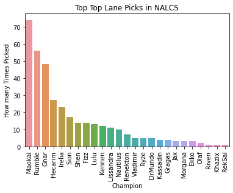

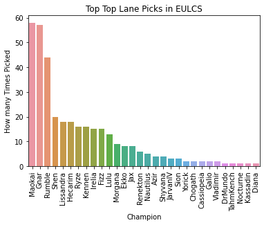

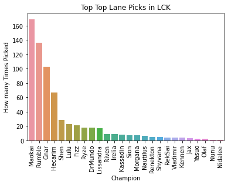

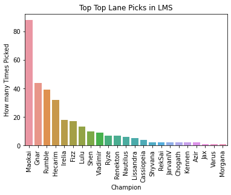

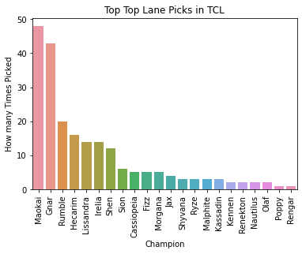

```python
plt.title("Top Top Lane Picks in NALCS")
plt.xticks(rotation=90)

# Sorting most viewed videos by row in descending order
resultNATop = resultNATop.sort_values(by=['SeasonPicks'], ascending=False)
# Creating bar plot
sns.barplot(x=resultNATop.index, y=resultNATop["SeasonPicks"])
plt.xlabel('Champion')
plt.ylabel('How many Times Picked')
plt.show()

plt.title("Top Top Lane Picks in EULCS")
plt.xticks(rotation=90)

# Sorting most viewed videos by row in descending order
resultEUTop = resultEUTop.sort_values(by=['SeasonPicks'], ascending=False)
# Creating bar plot
sns.barplot(x=resultEUTop.index, y=resultEUTop["SeasonPicks"])
plt.xlabel('Champion')
plt.ylabel('How many Times Picked')
plt.show()

plt.title("Top Top Lane Picks in LCK")
plt.xticks(rotation=90)

# Sorting most viewed videos by row in descending order
resultLCKTop = resultLCKTop.sort_values(by=['SeasonPicks'], ascending=False)
# Creating bar plot
sns.barplot(x=resultLCKTop.index, y=resultLCKTop["SeasonPicks"])
plt.xlabel('Champion')
plt.ylabel('How many Times Picked')
plt.show()


plt.title("Top Top Lane Picks in LMS")
plt.xticks(rotation=90)

# Sorting most viewed videos by row in descending order
resultLMSTop = resultLMSTop.sort_values(by=['SeasonPicks'], ascending=False)
# Creating bar plot
sns.barplot(x=resultLMSTop.index, y=resultLMSTop["SeasonPicks"])
plt.xlabel('Champion')
plt.ylabel('How many Times Picked')
plt.show()


plt.title("Top Top Lane Picks in TCL")
plt.xticks(rotation=90)

# Sorting most viewed videos by row in descending order
resultTCLTop = resultTCLTop.sort_values(by=['SeasonPicks'], ascending=False)
# Creating bar plot
sns.barplot(x=resultTCLTop.index, y=resultTCLTop["SeasonPicks"])
plt.xlabel('Champion')
plt.ylabel('How many Times Picked')
plt.show()
```

The first thing we can notice from our charts is that Maokai, Gnar, and Rumble are stable picks throughout all regions. For this reason we can ignore them because they dont show difference in gameplay in regions (it could mean they could just be strong champions). However the fourth and fifth most picked champ tells us something different. EULCS and TCL shows us that in their fourth/fifth most played champion has Lissandra while the rest of the regions dont. This is significant because Lissandra is more based on team-fighting (group vs group battles) because of her area of affect abilities(can hit multiple enemies at once) meaning that they prefer to have group battles compared to the other regions. Another significant detail we can notice here is that in the LMS and NALCS we see that Irelia is picked. Irelia is an interesting pick because she can dominate her lane. The intention behind picking her is so that she can win her lane 1v1 and make the other team spend more resources top lane to stop her from getting very strong. This is an interesting contrast between the Lissandra pick because Lissandra focuses more on team fighting while irelia is more well suited to 1v1's. LCK is also unique in how they pick Shen in their top fourth/fifth champion. Shen is character that can easily help other members of their team through roaming (going to other roles to help them fight). While EULCS/TCL top laners seem to be more team fight oriented, and NALCS/LMS prefer more self-centered toplaners, LCK shows that they would rather have their top-laner invest in helper their other roles get ahead.

Next we will be analyzing the picks for middle lane role.

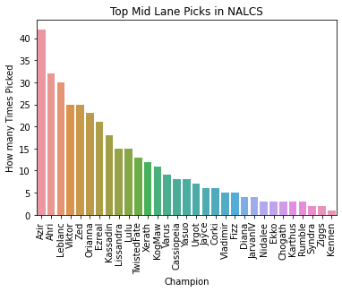

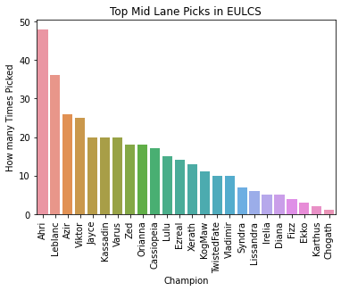

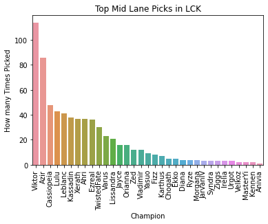

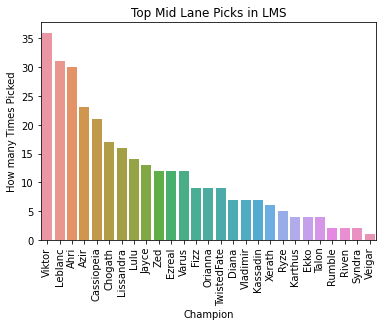

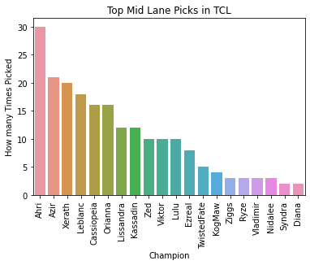

```python
plt.title("Top Mid Lane Picks in NALCS")
plt.xticks(rotation=90)

# Sorting most viewed videos by row in descending order
resultNAMid = resultNAMid.sort_values(by=['SeasonPicks'], ascending=False)
# Creating bar plot
sns.barplot(x=resultNAMid.index, y=resultNAMid["SeasonPicks"])
plt.xlabel('Champion')
plt.ylabel('How many Times Picked')
plt.show()

plt.title("Top Mid Lane Picks in EULCS")
plt.xticks(rotation=90)

# Sorting most viewed videos by row in descending order
resultEUMid = resultEUMid.sort_values(by=['SeasonPicks'], ascending=False)
# Creating bar plot
sns.barplot(x=resultEUMid.index, y=resultEUMid["SeasonPicks"])
plt.xlabel('Champion')
plt.ylabel('How many Times Picked')
plt.show()

plt.title("Top Mid Lane Picks in LCK")
plt.xticks(rotation=90)

# Sorting most viewed videos by row in descending order
resultLCKMid = resultLCKMid.sort_values(by=['SeasonPicks'], ascending=False)
# Creating bar plot
sns.barplot(x=resultLCKMid.index, y=resultLCKMid["SeasonPicks"])
plt.xlabel('Champion')
plt.ylabel('How many Times Picked')
plt.show()


plt.title("Top Mid Lane Picks in LMS")
plt.xticks(rotation=90)

# Sorting most viewed videos by row in descending order
resultLMSMid = resultLMSMid.sort_values(by=['SeasonPicks'], ascending=False)
# Creating bar plot
sns.barplot(x=resultLMSMid.index, y=resultLMSMid["SeasonPicks"])
plt.xlabel('Champion')
plt.ylabel('How many Times Picked')
plt.show()


plt.title("Top Mid Lane Picks in TCL")
plt.xticks(rotation=90)

# Sorting most viewed videos by row in descending order
resultTCLMid = resultTCLMid.sort_values(by=['SeasonPicks'], ascending=False)
# Creating bar plot
sns.barplot(x=resultTCLMid.index, y=resultTCLMid["SeasonPicks"])
plt.xlabel('Champion')
plt.ylabel('How many Times Picked')
plt.show()
```

Here we can see more variety in the top picks of the season than the top laners. First off we notice Azir and Viktor as top picks for NALCS,LCK and LMS. Azir(NALCS top pick) and Viktor(LCK top pick) are a characters that which excels at doing consistant damage and team fighting. This is an interesting contrast to the TCL and EU who has Ahri as their most picked character. Ahri excels at roaming and picking off enemy characters. (Quickly taking down a single character). This shows that NA, LCK and the LMS prefer more drawn out fights while TCL and EU prefer to take quicker interacts to gain advantages.

Next we will be analyzing support picks per region.

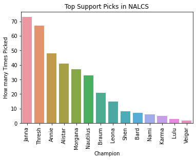

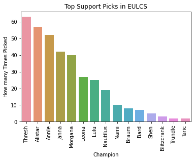

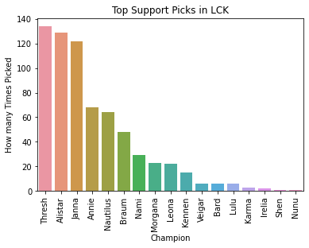

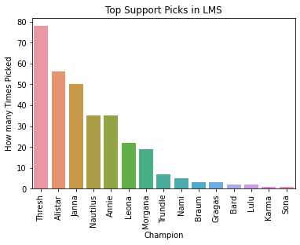

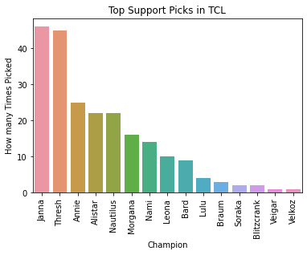

```python
plt.title("Top Support Picks in NALCS")
plt.xticks(rotation=90)

# Sorting most viewed videos by row in descending order
resultNASup = resultNASup.sort_values(by=['SeasonPicks'], ascending=False)
# Creating bar plot
sns.barplot(x=resultNASup.index, y=resultNASup["SeasonPicks"])
plt.xlabel('Champion')
plt.ylabel('How many Times Picked')
plt.show()



plt.title("Top Support Picks in EULCS")
plt.xticks(rotation=90)

# Sorting most viewed videos by row in descending order
resultEUSup = resultEUSup.sort_values(by=['SeasonPicks'], ascending=False)
# Creating bar plot
sns.barplot(x=resultEUSup.index, y=resultEUSup["SeasonPicks"])
plt.xlabel('Champion')
plt.ylabel('How many Times Picked')
plt.show()

plt.title("Top Support Picks in LCK")
plt.xticks(rotation=90)

# Sorting most viewed videos by row in descending order
resultLCKSup = resultLCKSup.sort_values(by=['SeasonPicks'], ascending=False)
# Creating bar plot
sns.barplot(x=resultLCKSup.index, y=resultLCKSup["SeasonPicks"])
plt.xlabel('Champion')
plt.ylabel('How many Times Picked')
plt.show()


plt.title("Top Support Picks in LMS")
plt.xticks(rotation=90)

# Sorting most viewed videos by row in descending order
resultLMSSup = resultLMSSup.sort_values(by=['SeasonPicks'], ascending=False)
# Creating bar plot
sns.barplot(x=resultLMSSup.index, y=resultLMSSup["SeasonPicks"])
plt.xlabel('Champion')
plt.ylabel('How many Times Picked')
plt.show()


plt.title("Top Support Picks in TCL")
plt.xticks(rotation=90)

# Sorting most viewed videos by row in descending order
resultTCLSup = resultTCLSup.sort_values(by=['SeasonPicks'], ascending=False)
# Creating bar plot
sns.barplot(x=resultTCLSup.index, y=resultTCLSup["SeasonPicks"])
plt.xlabel('Champion')
plt.ylabel('How many Times Picked')
plt.show()
```

For supports we will be talking mostly about the top 3 picks of each region. The champions we see pretty often in these spots are Janna, Thresh, Annie, and Alistar. Janna and Annie are casters(Using spells for utility) and play more passive(less fighting) while Alistar and Thresh prefer to force engagements and play more aggresive(more fighting). Through this we can see what regions like to play more passive or agressive in the bottom lane. Using the knowledge we can see that NALCS and TCL prefer to play more passive as two of their top three picks are Janna and Annie, while EULCS ,LCK and LMS prefer to play more aggressive bottom laners to gain leads.

Next we will be analyzing the jungle role character picks per region.

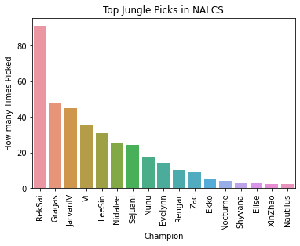

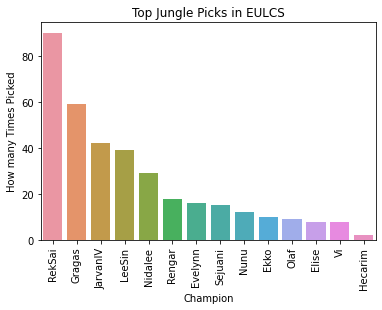

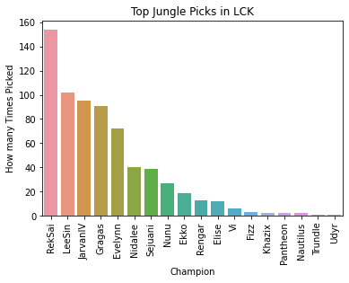

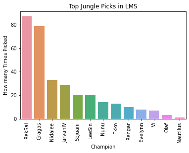

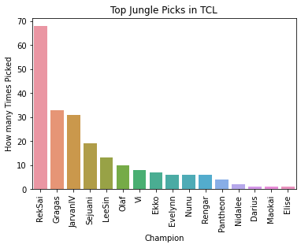

```python
plt.title("Top Jungle Picks in NALCS")
plt.xticks(rotation=90)

# Sorting most viewed videos by row in descending order
resultNAJg = resultNAJg.sort_values(by=['SeasonPicks'], ascending=False)
# Creating bar plot
sns.barplot(x=resultNAJg.index, y=resultNAJg["SeasonPicks"])
plt.xlabel('Champion')
plt.ylabel('How many Times Picked')
plt.show()



plt.title("Top Jungle Picks in EULCS")
plt.xticks(rotation=90)

# Sorting most viewed videos by row in descending order
resultEUJg = resultEUJg.sort_values(by=['SeasonPicks'], ascending=False)
# Creating bar plot
sns.barplot(x=resultEUJg.index, y=resultEUJg["SeasonPicks"])
plt.xlabel('Champion')
plt.ylabel('How many Times Picked')
plt.show()

plt.title("Top Jungle Picks in LCK")
plt.xticks(rotation=90)

# Sorting most viewed videos by row in descending order
resultLCKJg = resultLCKJg.sort_values(by=['SeasonPicks'], ascending=False)
# Creating bar plot
sns.barplot(x=resultLCKJg.index, y=resultLCKJg["SeasonPicks"])
plt.xlabel('Champion')
plt.ylabel('How many Times Picked')
plt.show()


plt.title("Top Jungle Picks in LMS")
plt.xticks(rotation=90)

# Sorting most viewed videos by row in descending order
resultLMSJg = resultLMSJg.sort_values(by=['SeasonPicks'], ascending=False)
# Creating bar plot
sns.barplot(x=resultLMSJg.index, y=resultLMSJg["SeasonPicks"])
plt.xlabel('Champion')
plt.ylabel('How many Times Picked')
plt.show()


plt.title("Top Jungle Picks in TCL")
plt.xticks(rotation=90)

# Sorting most viewed videos by row in descending order
resultTCLJg = resultTCLJg.sort_values(by=['SeasonPicks'], ascending=False)
# Creating bar plot
sns.barplot(x=resultTCLJg.index, y=resultTCLJg["SeasonPicks"])
plt.xlabel('Champion')
plt.ylabel('How many Times Picked')
plt.show()
```

First of all I'd like to point out the Jungle does not have a lane. Their role is to help all lanes as they dont have a lane. They mostly remain in between lanes rather than the other roles which reside in their respective lanes.

Since all the regions top pick was RekSai we can disregard that spot because of its irrelevance to discerning differences in our their playstyle preference. If we look at the second to fourth most picked characters it also tells us a interesting story about each region. Although we see characters like Gragas and JarvanIV consistantly at these ranks the creativity shows in the picks that are different. In the LMS, LCK and EULCS we characters like lee sin and nidalee picked in this range. Lee sin and Nidalee are both very difficult characters that excels at picking characters off(taking them down quickly). This means they seek more aggressive(looking for fights) engagements to gain leads quickly. Where as TCL and NA choose characters like Vi and Sejuani. They both excel at locking down specific characters so their team can do damage to them. Although they perform similar functions (picking) as lee sin and nidalee, they provide more tools for their team but need their team around them to be effective while Lee Sin and Nidalee can do it themselves.

Next we will be analyzing the gold distribution between the roles of the Top Laner, Mid Laner, Jungler, and ADC. Notice how we excluded the support. This is because since the support is supposed to make their ADC as strong as possible, the ADC's gold is a better indicator of how well the bottom lane is doing.

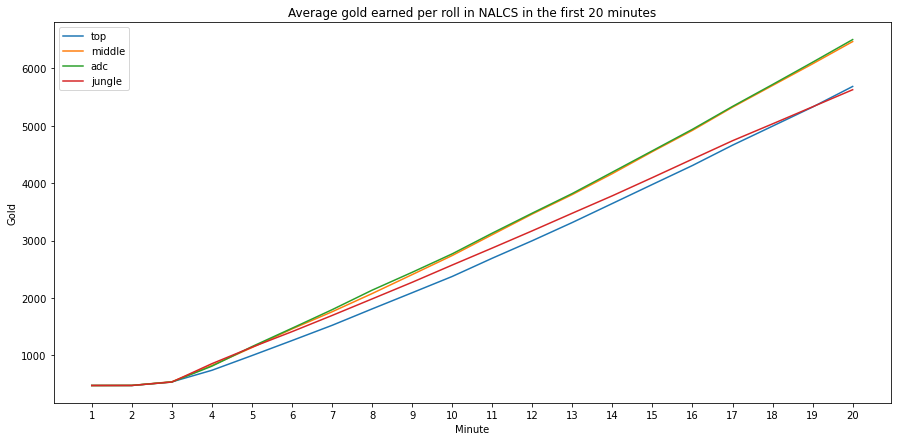

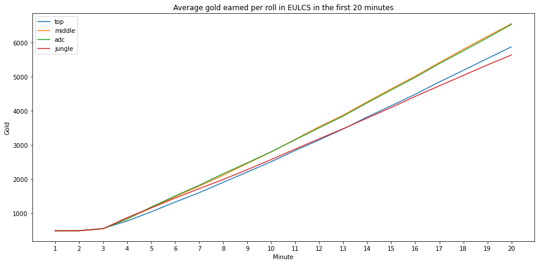

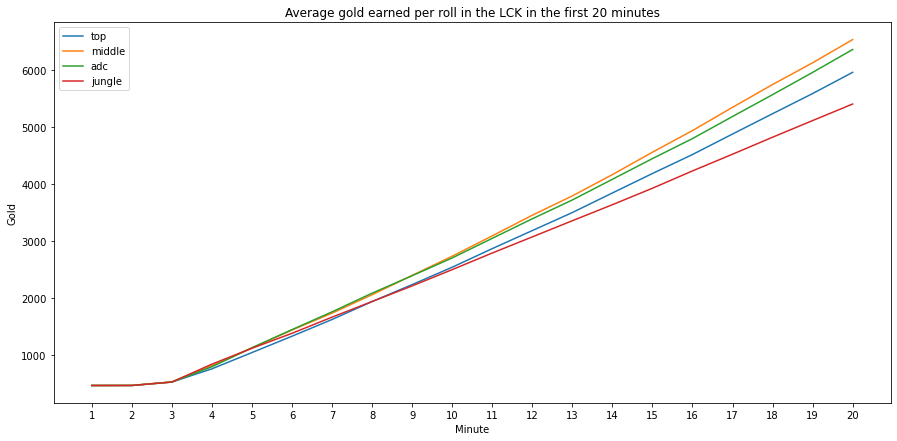

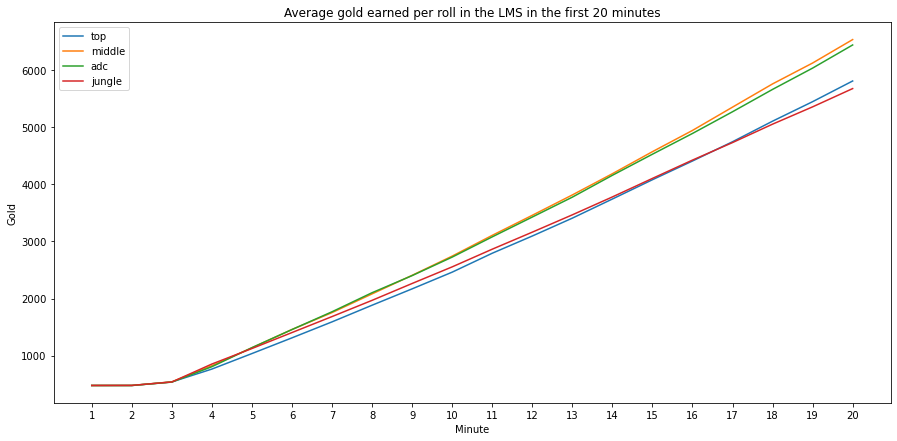

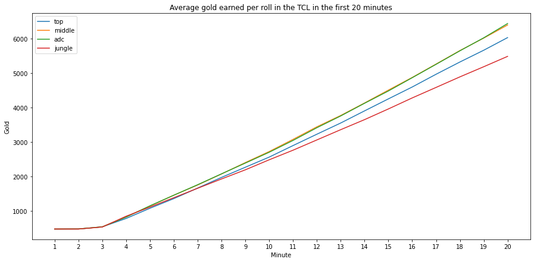

```python
#Use helper function made to get all winning teams towerData.
finListNA = getList(nalcs5)

plt.figure(figsize=(15,7))
plt.title('Average gold earned per roll in NALCS in the first 20 minutes')
plt.xlabel('Minute')
plt.ylabel('Gold')
x = 0

#plot all NALCS data
for role in finListNA:
    plt.plot(minutes,role, label = rolesOrder[x])
    plt.legend()
    x = x + 1

plt.show()

finListEU = getList(eulcs5)

#plot all EULCS data
plt.figure(figsize=(15,7))
plt.title('Average gold earned per roll in EULCS in the first 20 minutes')
plt.xlabel('Minute')
plt.ylabel('Gold')
y = 0
for role in finListEU:
    plt.plot(minutes,role, label = rolesOrder[y])
    plt.legend()
    y = y + 1

finListLCK = getList(lck5)

#plot all LCK data
plt.figure(figsize=(15,7))
plt.title('Average gold earned per roll in the LCK in the first 20 minutes')
plt.xlabel('Minute')
plt.ylabel('Gold')
y = 0
for role in finListLCK:
    plt.plot(minutes,role, label = rolesOrder[y])
    plt.legend()
    y = y + 1

plt.show()

finListLMS = getList(lms5)

#plot all LMS data
plt.figure(figsize=(15,7))
plt.title('Average gold earned per roll in the LMS in the first 20 minutes')
plt.xlabel('Minute')
plt.ylabel('Gold')
y = 0
for role in finListLMS:
    plt.plot(minutes,role, label = rolesOrder[y])
    plt.legend()
    y = y + 1

plt.show()

finListTCL = getList(tcl5)

#plot all TCL data
plt.figure(figsize=(15,7))
plt.title('Average gold earned per roll in the TCL in the first 20 minutes')
plt.xlabel('Minute')
plt.ylabel('Gold')
y = 0
for role in finListTCL:
    plt.plot(minutes,role, label = rolesOrder[y])
    plt.legend()
    y = y + 1

plt.show()
```

In this section we utilize line graphs for each region to see how much gold each role gets per region in relative to the other golds. This is the easiest indicator of what role different regions like to give their gold too.

Next we will be using a heatmap to analyze what towers certain regions like to take compared to others.

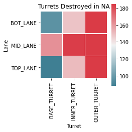

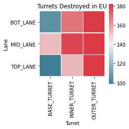

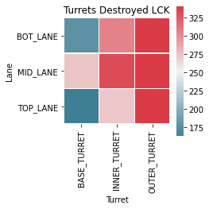

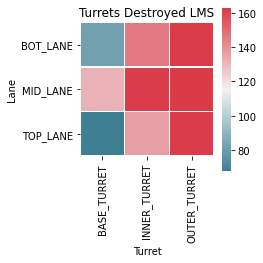

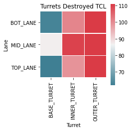

```python
naTower = organize(towerListNA)
df = pd.DataFrame(naTower, columns = ['Lane', 'Turret','Count'])
df = df.pivot(index=['Lane'], columns='Turret', values='Count')

euTower = organize(towerListEU)
df2 = pd.DataFrame(euTower, columns = ['Lane', 'Turret','Count'])
df2 = df2.pivot(index=['Lane'], columns='Turret', values='Count')

lckTower = organize(towerListLCK)
df3 = pd.DataFrame(lckTower, columns = ['Lane', 'Turret','Count'])
df3 = df3.pivot(index=['Lane'], columns='Turret', values='Count')

lmsTower = organize(towerListLMS)
df4 = pd.DataFrame(lmsTower, columns = ['Lane', 'Turret','Count'])
df4 = df4.pivot(index=['Lane'], columns='Turret', values='Count')

tclTower = organize(towerListTCL)
df5 = pd.DataFrame(tclTower, columns = ['Lane', 'Turret','Count'])
df5 = df5.pivot(index=['Lane'], columns='Turret', values='Count')

cmap = sns.diverging_palette(220,10, as_cmap=True)



f, ax = plt.subplots(figsize=(3,3))
plt.title('Turrets Destroyed in NA')
sns.heatmap(df, cmap=cmap, square=True, linewidths=.5, ax=ax)
plt.show()

f, ax = plt.subplots(figsize=(3,3))
plt.title('Turrets Destroyed in EU')
sns.heatmap(df2, cmap=cmap, square=True, linewidths=.5, ax=ax)
plt.show()

f, ax = plt.subplots(figsize=(3,3))
plt.title('Turrets Destroyed LCK')
sns.heatmap(df3, cmap=cmap, square=True, linewidths=.5, ax=ax)
plt.show()

f, ax = plt.subplots(figsize=(3,3))
plt.title('Turrets Destroyed LMS')
sns.heatmap(df4, cmap=cmap, square=True, linewidths=.5, ax=ax)
plt.show()

f, ax = plt.subplots(figsize=(3,3))
plt.title('Turrets Destroyed TCL')
sns.heatmap(df5, cmap=cmap, square=True, linewidths=.5, ax=ax)
plt.show()
```

From these heatmaps, we can tell about how regions like to approach taking turrets. Each row represents one of the three lanes that exist on the map. And each column represents one of the three turrets protecting each lane. The turret farthest from the base is called OUTER_TURRET while the closest is BASE_TURRET. There is also a turret between these two that is called the INNER_TURRET. The more red the square is, the more often that turret has been taken while the more blue a square is, the less its been taken.

First we can look at NALCS's heatmap. It looks very symetrical. This shows us they seem to prefer to plow straight through the middle lane. There is also a very slight bias to take the inner bot turret rather than the inner top turret.

The TCL league seems to play similar to NALCS's. However it seems the colors on their heatmap is even more symetrical which suggests the play more mid based than all the other teams.

Then if we look at EULCS's,LMS's, and LCK's heatmap we start to see a different story. They are more likely to push through bottom lane as well as the middle lane. They also tend to leave the inner top turrets alone and focus more on the bottom turrets when trying to make their way into the enemy base. This shows that they tend to play mid and botside.

1. Conclusion

Now that we have all the data in clear graphs, lets combine our knowledge together to see if we can depict specific gameplans and styles per region.

From the data we have gathered we can see a more holistic idea of the gameplan certain regions may prefer over others. First we will start with NA. We know that NA likes to have more solo oriented top laners, mid laners with consistant damage,Team oriented Junglers and Passive Bottom Laners. With the mid and ADC having similar gold net worth we can say that they probably stay apart so they dont take gold from each other. This probably means their game plan is to play passive bot so their ADC can get gold consistantly. This means that NA excels in playing slow and in more team oriented fights near the bottom and mid lane. They leave their solo oriented top laner to stay in the top lane, while the mid laner and bottom lane work together with the Jungler to find advantages due to the Junglers team oriented style of play.

For EU we can say that they like more teamfight oriented toplaners, with aggressive midlaners,junglers and support. Their gameplan can be to look for risky aggressive plays in the bottom lane, to take their tower as the heatmap suggests. This makes sense because the gold chart suggests this because the jungler is helping the adc and mid laner take the resources on their plays making him fall behind in gold, while the top laner is left alone to consistantly gain gold and pull them together during team fights if more riskier plays dont play out. This is a great contrast to NA's playstyle because of how EU likes to have an aggressive mid, jungle and support to completely sieze control of the bottom to mid lane area of the map.

For LCK we can see roam heavy top laners, with Consistant damage Mid laners, and agressive junglers, with Aggressive supports. This is interesting because now we see a team that prefers a roam heavy top laner. Their turret taking patterns suggest they also like to make aggressive plays bot, with the safety net of having the toplaner be able to come to their aid at any moment. Usually when Top Laners who don't excel at roaming move around the map, they lose gold while spending time aiding their teammates. But with the top laner having such fast roam tools, he can have global map prescence without losing much gold by missed farm on the top lane allowing him to get more gold. We can see that LCK relies on helping their mid laner to get ahead. Doing so allows the mid laner to have alot more control of the map since he can walk to both top and bot lane at a shorter distance than the other laners. This means that their playstyle is more mid based. In turn it allows them to make quicker and more effective plays in the bottom lane which in turn allows them to destroy bottom lane turrets like the heatMap suggests.

For LMS we can see solo fight oriented top laner, consistant damage midlaners, Aggressive supports laners, and aggressive junglers. As the heatmap suggests, we can see that this region like to use their aggressive support and aggressive junglers to make plays in the bottom lane to sieze a lead in the bottom lane, in turn taking their the other teams bottom lane towers. This is an interesting contrast from LCK because of how they seem to prefer aggressive support and jungler combo compared to the LCK's interesting way of utilizing the Top,Jungler, and Support to make plays.

6.Ending Notes This tutorial has been a very educational and intruiging way to analyze league of legends pro play. When it comes to my question of how the regions differ in playstyle, I conclude that they are different. Although some regions play more similar to others, we can clearly see different ways they approach gaining the advantage. They each have their own specific way of getting ahead and try to utilize that to win in the way they know best how to.

The graphs of the top picked champion per role and region showed that they were alot of similar picks. This is because of a games ability to develop META(Most Efficient Tactic Available). This could just happen to be that during that time of the game certain characters were strong or even unbalanced to the point where teams must have picked them. This explains why our graphs may have been skewed, but where creativity shines is when those characters are not picked. Thats when we see the difference in playstyle of character and decision making.

The heatmap of turrest taken also showed a different in how they liked to approach the enemy base. NA and TCL seemed to like to take their mid turrets and not give to much attention to the side turrets, while LCK EU and LMS seemed to like putting the resources into taking the inner bottom lane turrets.

These pro players play this game tirelesly trying to find the best way to succesfully play this game. These small gameplay decision shape how they like to approach the game therefore creating their own style. This is fascinating to see, because you really get to peek into these players mind when looking at the data. And maybe you can figure out a strategy that can take your team to the top.